# Linear Regression: Government Transfer and Poverty Reduction in Brazil

Quantitative Methods for Humanities

CUNEF Universidad

# Introduction

This case study studies whether additional government transfers improved education, literacy, and poverty outcomes in Brazilian municipalities.

Until 1991, some transfers depended on population cutoffs. Municipalities just above a cutoff received more resources than municipalities just below it. This allows us to use a **regression discontinuity design (RDD)**.

# The Data

The data set contains the following variables

- `pop82`: Population in 1982.
- `poverty80`: Poverty rate in 1980.
- `poverty91`: Poverty rate in 1991.
- `educ80`: Average years of education in 1980.
- `educ91`: Average years of education in 1991.
- `literate91`: Literacy rate in 1991.
- `state`: State.
- `region`: Region.
- `id`: Municipality ID.
- `year`: Year of measurement.

```r
transfer <- read.csv("transfer.csv")
head(transfer) # first observations
```

```
##    X state region literate91   educ91 poverty91 poverty80 educ80 pop82
## 1 55    AC      N  0.7278106 3.873065 0.6358200    0.6608    1.7 13937
## 2 60    AC      N  0.4770992 2.480469 0.7512400    0.7950    1.0 19613
## 3 65    AC      N  0.7186312 3.216730 0.6679699    0.4121    0.9  9343
## 4 70    AC      N  0.7329843 3.966312 0.5381100    0.4131    0.8  9728
## 5 71    AC      N  0.5520231 3.005882 0.6924300    0.4808    1.0 23592
## 6 73    AC      N  0.6898396 3.887701 0.5912600    0.5765    1.5 14701
```

```r
nrow(transfer) # number of observations
```

```
## [1] 1787
```

# Q1. Regression Discontinuity Design Assumptions

The key assumption is **continuity at the cutoff** with respect to any covariate:

> Municipalities just below and just above the population cutoff should behave similar with respect any pretreatment variable.

In this application, municipalities slightly below 10,188 inhabitants should be similar to municipalities slightly above 10,188 inhabitants, except that the latter received more transfers.

A violation would occur if municipalities manipulated population numbers to move above the cutoff, or if municipalities above the cutoff were already different before the policy.

- **The main advantage is** that the design compares very similar municipalities near the threshold.
- **The main disadvantage** is that the estimate is local: it applies mainly to municipalities close to the cutoff.

# Q2. Creating a Variable for Proximity to the Cutoff

The cutoffs are 10,188, 13,584, and 16,980.

```r
transfer$cutoff <- 10188
transfer$cutoff[abs(transfer$pop82 - 13584) < abs(transfer$pop82 - transfer$cutoff)] <- 13584
transfer$cutoff[abs(transfer$pop82 - 16980) < abs(transfer$pop82 - transfer$cutoff)] <- 16980

transfer$diff_cutoff <- transfer$pop82 - transfer$cutoff
transfer$dist_cutoff <- 100 * transfer$diff_cutoff / transfer$cutoff
transfer$above <- ifelse(transfer$diff_cutoff >= 0, 1, 0)

head(transfer[, c("pop82", "cutoff", "diff_cutoff", "dist_cutoff", "above")])
```

```
##   pop82 cutoff diff_cutoff dist_cutoff above
## 1 13937  13584         353    2.598645     1
## 2 19613  16980        2633   15.506478     1
## 3  9343  10188        -845   -8.294071     0
## 4  9728  10188        -460   -4.515116     0
## 5 23592  16980        6612   38.939929     1
## 6 14701  13584        1117    8.222909     1
```

`dist_cutoff` measures the distance from the closest cutoff as a percentage. Negative values are below the cutoff; positive values are above it.

# Q3. Estimating Causal Effects Near the Cutoff

We keep municipalities within 3 percentage points of the closest cutoff.

```r
transfer3 <- subset(transfer, abs(dist_cutoff) <= 3)
nrow(transfer3)
```

```
## [1] 297
```

Because `dist_cutoff` is centered at zero, the coefficient on `above` is the estimated jump at the cutoff.

```r
educ_rdd <- lm(educ91 ~ above * dist_cutoff, data = transfer3)
lit_rdd <- lm(literate91 ~ above * dist_cutoff, data = transfer3)
pov_rdd <- lm(poverty91 ~ above * dist_cutoff, data = transfer3)

summary(educ_rdd)
```

```
##
## Call:
## lm(formula = educ91 ~ above * dist_cutoff, data = transfer3)
##
## Residuals:
##     Min      1Q  Median      3Q     Max
## -3.3560 -1.1572  0.0069  1.0733  2.8908
##
## Coefficients:
##                   Estimate Std. Error t value Pr(>|t|)
## (Intercept)        4.40728    0.22773  19.353   <2e-16 ***
## above              0.58364    0.31549   1.850   0.0653 .
## dist_cutoff        0.05922    0.13626   0.435   0.6641
## above:dist_cutoff -0.21477    0.18508  -1.160   0.2468
## ---
## Signif. codes:  0 '***' 0.001 '**' 0.01 '*' 0.05 '.' 0.1 ' ' 1
##
## Residual standard error: 1.38 on 293 degrees of freedom
## Multiple R-squared:  0.03034,    Adjusted R-squared:  0.02041
## F-statistic: 3.056 on 3 and 293 DF,  p-value: 0.02874
```

```r
summary(lit_rdd)
```

```
##
## Call:
## lm(formula = literate91 ~ above * dist_cutoff, data = transfer3)
##
## Residuals:
##      Min       1Q   Median       3Q      Max
## -0.50902 -0.13431  0.05412  0.13692  0.23641
##
## Coefficients:
##                    Estimate Std. Error t value Pr(>|t|)
## (Intercept)        0.775610   0.026212  29.590   <2e-16 ***
## above              0.055645   0.036314   1.532    0.127
## dist_cutoff        0.006948   0.015684   0.443    0.658
## above:dist_cutoff -0.019549   0.021303  -0.918    0.360
## ---
## Signif. codes:  0 '***' 0.001 '**' 0.01 '*' 0.05 '.' 0.1 ' ' 1
##
## Residual standard error: 0.1588 on 293 degrees of freedom
## Multiple R-squared:  0.0247, Adjusted R-squared:  0.01471
## F-statistic: 2.473 on 3 and 293 DF,  p-value: 0.06181
```

```r
summary(pov_rdd)
```

```
##
## Call:
## lm(formula = poverty91 ~ above * dist_cutoff, data = transfer3)
##
## Residuals:
##      Min       1Q   Median       3Q      Max
## -0.53238 -0.16850  0.04041  0.19472  0.36937
##
## Coefficients:
##                   Estimate Std. Error t value Pr(>|t|)
## (Intercept)        0.59167    0.03709  15.952   <2e-16 ***
## above             -0.06033    0.05139  -1.174    0.241
## dist_cutoff       -0.03382    0.02219  -1.524    0.129
## above:dist_cutoff  0.06459    0.03014   2.143    0.033 *
## ---
## Signif. codes:  0 '***' 0.001 '**' 0.01 '*' 0.05 '.' 0.1 ' ' 1
##
## Residual standard error: 0.2247 on 293 degrees of freedom
## Multiple R-squared:  0.03451,    Adjusted R-squared:  0.02463
## F-statistic: 3.491 on 3 and 293 DF,  p-value: 0.01612
```

```r
rdd_results <- data.frame(
  outcome = c("Education", "Literacy", "Poverty"),
  estimate = c(coef(educ_rdd)["above"], coef(lit_rdd)["above"], coef(pov_rdd)["above"])
)
rdd_results$estimate <- round(rdd_results$estimate, 3)
rdd_results
```

```
##     outcome estimate
## 1 Education    0.584
## 2  Literacy    0.056
## 3   Poverty   -0.060
```

The estimates suggest that municipalities just above the cutoff had higher education, higher literacy, and lower poverty than municipalities just below the cutoff. This is consistent with a positive effect of government transfers. But be careful with statistical significance: so far non of the estimated average treatment effect are significantly different from zero based on their p-values.

# Q4. Visualizing the Analysis

The vertical line marks the cutoff. The two fitted lines are estimated separately below and above the cutoff.

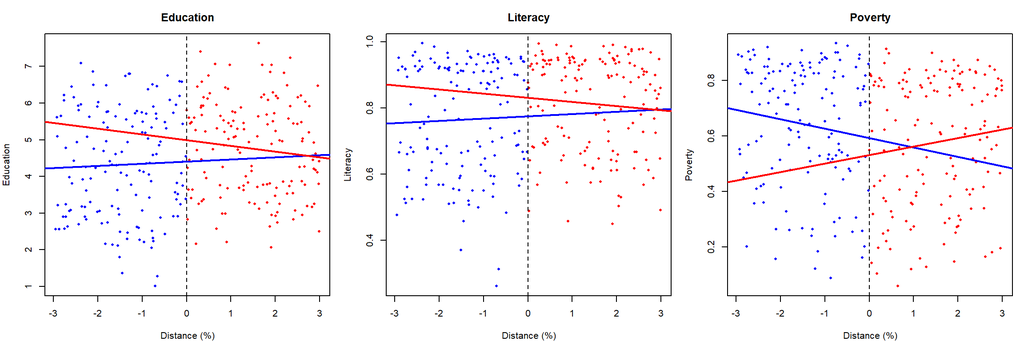

```r
cols <- ifelse(transfer3$above == 1, "red", "blue")

par(mfrow = c(1, 3), mar = c(4, 4, 3, 1))

plot(transfer3$dist_cutoff, transfer3$educ91, pch = 16, cex = 0.6,
     col = cols, xlab = "Distance (%)", ylab = "Education", main = "Education")
abline(v = 0, lty = 2)
abline(lm(educ91 ~ dist_cutoff, data = subset(transfer3, above == 0)), col = "blue", lwd = 2)
abline(lm(educ91 ~ dist_cutoff, data = subset(transfer3, above == 1)), col = "red", lwd = 2)

plot(transfer3$dist_cutoff, transfer3$literate91, pch = 16, cex = 0.6,
     col = cols, xlab = "Distance (%)", ylab = "Literacy", main = "Literacy")
abline(v = 0, lty = 2)
abline(lm(literate91 ~ dist_cutoff, data = subset(transfer3, above == 0)), col = "blue", lwd = 2)
abline(lm(literate91 ~ dist_cutoff, data = subset(transfer3, above == 1)), col = "red", lwd = 2)

plot(transfer3$dist_cutoff, transfer3$poverty91, pch = 16, cex = 0.6,
     col = cols, xlab = "Distance (%)", ylab = "Poverty", main = "Poverty")
abline(v = 0, lty = 2)
abline(lm(poverty91 ~ dist_cutoff, data = subset(transfer3, above == 0)), col = "blue", lwd = 2)
abline(lm(poverty91 ~ dist_cutoff, data = subset(transfer3, above == 1)), col = "red", lwd = 2)
```

```r
par(mfrow = c(1, 1))
```

The plots are noisy, but a positive jump for education and literacy, and a negative jump for poverty, would support the idea that transfers improved outcomes.

# Q5. Difference-in-Means Analysis

Now we compare average outcomes above and below the cutoff, using the same 3 percentage-point window.

```r
educ_dim <- lm(educ91 ~ above, data = transfer3)
lit_dim <- lm(literate91 ~ above, data = transfer3)
pov_dim <- lm(poverty91 ~ above, data = transfer3)

summary(educ_dim)
```

```
##
## Call:
## lm(formula = educ91 ~ above, data = transfer3)
##
## Residuals:
##     Min      1Q  Median      3Q     Max
## -3.3122 -1.1351  0.0439  1.1579  2.8699
##
## Coefficients:
##             Estimate Std. Error t value Pr(>|t|)
## (Intercept)   4.3216     0.1141  37.862  < 2e-16 ***
## above         0.4367     0.1601   2.728  0.00675 **
## ---
## Signif. codes:  0 '***' 0.001 '**' 0.01 '*' 0.05 '.' 0.1 ' ' 1
##
## Residual standard error: 1.379 on 295 degrees of freedom
## Multiple R-squared:  0.02461,    Adjusted R-squared:  0.0213
## F-statistic: 7.443 on 1 and 295 DF,  p-value: 0.006752
```

```r
summary(lit_dim)
```

```
##
## Call:
## lm(formula = literate91 ~ above, data = transfer3)
##
## Residuals:
##      Min       1Q   Median       3Q      Max
## -0.50388 -0.13156  0.04785  0.13951  0.22995
##
## Coefficients:
##             Estimate Std. Error t value Pr(>|t|)
## (Intercept)  0.76556    0.01312  58.347   <2e-16 ***
## above        0.04685    0.01840   2.546   0.0114 *
## ---
## Signif. codes:  0 '***' 0.001 '**' 0.01 '*' 0.05 '.' 0.1 ' ' 1
##
## Residual standard error: 0.1585 on 295 degrees of freedom
## Multiple R-squared:  0.0215, Adjusted R-squared:  0.01819
## F-statistic: 6.483 on 1 and 295 DF,  p-value: 0.0114
```

```r
summary(pov_dim)
```

```
##
## Call:
## lm(formula = poverty91 ~ above, data = transfer3)
##
## Residuals:
##      Min       1Q   Median       3Q      Max
## -0.55216 -0.16889  0.05464  0.19963  0.33515
##
## Coefficients:
##             Estimate Std. Error t value Pr(>|t|)
## (Intercept)  0.64058    0.01868  34.291   <2e-16 ***
## above       -0.06324    0.02620  -2.414   0.0164 *
## ---
## Signif. codes:  0 '***' 0.001 '**' 0.01 '*' 0.05 '.' 0.1 ' ' 1
##
## Residual standard error: 0.2257 on 295 degrees of freedom
## Multiple R-squared:  0.01937,    Adjusted R-squared:  0.01604
## F-statistic: 5.826 on 1 and 295 DF,  p-value: 0.0164
```

```r
comparison <- data.frame(
  outcome = c("Education", "Literacy", "Poverty"),
  difference_in_means = c(coef(educ_dim)["above"], coef(lit_dim)["above"], coef(pov_dim)["above"]),
  rdd_estimate = c(coef(educ_rdd)["above"], coef(lit_rdd)["above"], coef(pov_rdd)["above"])
)
comparison$difference_in_means <- round(comparison$difference_in_means, 3)
comparison$rdd_estimate <- round(comparison$rdd_estimate, 3)
comparison
```

```
##     outcome difference_in_means rdd_estimate
## 1 Education               0.437        0.584
## 2  Literacy               0.047        0.056
## 3   Poverty              -0.063       -0.060
```

The difference-in-means comparison is simpler, but it assumes that municipalities above and below the cutoff are directly comparable inside the window.

The RDD estimates are usually more appropriate because they also control for distance from the cutoff. This allows outcomes to vary smoothly with population.

# Q6. Varying the Analysis Window

We repeat the RDD analysis using windows from 1 to 5 percentage points.

```r
window_results <- data.frame(window = 1:5, education = NA, literacy = NA, poverty = NA, n = NA)

for (w in 1:5) {
  data_w <- subset(transfer, abs(dist_cutoff) <= w)
  educ_w <- lm(educ91 ~ above * dist_cutoff, data = data_w)
  lit_w <- lm(literate91 ~ above * dist_cutoff, data = data_w)
  pov_w <- lm(poverty91 ~ above * dist_cutoff, data = data_w)

  window_results$education[w] <- coef(educ_w)["above"]
  window_results$literacy[w] <- coef(lit_w)["above"]
  window_results$poverty[w] <- coef(pov_w)["above"]
  window_results$n[w] <- nrow(data_w)
}

window_results[, c("education", "literacy", "poverty")] <-
  round(window_results[, c("education", "literacy", "poverty")], 3)
window_results
```

```
##   window education literacy poverty   n
## 1      1     0.215    0.037  -0.040 107
## 2      2     0.406    0.054  -0.046 202
## 3      3     0.584    0.056  -0.060 297
## 4      4     0.712    0.075  -0.081 391
## 5      5     0.690    0.065  -0.083 479
```

As the window becomes wider, we use more observations. This can improve precision, but it also includes municipalities farther from the cutoff. Similar estimates across windows would make the results more robust.

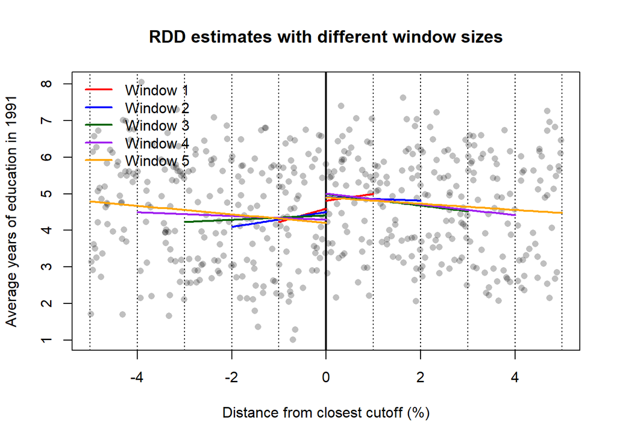

```r
# Plot all municipalities within the widest window
data_5 <- subset(transfer, abs(dist_cutoff) <= 5)

plot(data_5$dist_cutoff, data_5$educ91,
     xlab = "Distance from closest cutoff (%)",
     ylab = "Average years of education in 1991",
     main = "RDD estimates with different window sizes",
     pch = 16, col = rgb(0, 0, 0, 0.25))

# Cutoff
abline(v = 0, lwd = 2)

# Window limits
abline(v = c(-1, 1), lty = 3)
abline(v = c(-2, 2), lty = 3)
abline(v = c(-3, 3), lty = 3)
abline(v = c(-4, 4), lty = 3)
abline(v = c(-5, 5), lty = 3)

# Fit and plot one RDD line for each window
colors <- c("red", "blue", "darkgreen", "purple", "orange")

for (w in 1:5) {
  data_w <- subset(transfer, abs(dist_cutoff) <= w)
  model_w <- lm(educ91 ~ above * dist_cutoff, data = data_w)

  left_side <- data.frame(
    dist_cutoff = seq(-w, 0, length.out = 50),
    above = 0
  )

  right_side <- data.frame(
    dist_cutoff = seq(0, w, length.out = 50),
    above = 1
  )

  lines(left_side$dist_cutoff,
        predict(model_w, newdata = left_side),
        col = colors[w], lwd = 2)

  lines(right_side$dist_cutoff,
        predict(model_w, newdata = right_side),
        col = colors[w], lwd = 2)
}

legend("topleft",
       legend = paste("Window", 1:5),
       col = colors,
       lwd = 2,
       bty = "n")
```

# Q7. Validity Check Using Pre-Treatment Data

We repeat the same analysis using outcomes measured before the transfers.

```r
educ80_rdd <- lm(educ80 ~ above * dist_cutoff, data = transfer3)
pov80_rdd <- lm(poverty80 ~ above * dist_cutoff, data = transfer3)

summary(educ80_rdd)
```

```
##
## Call:
## lm(formula = educ80 ~ above * dist_cutoff, data = transfer3)
##
## Residuals:
##      Min       1Q   Median       3Q      Max
## -1.60226 -0.83419 -0.04423  0.75747  2.65263
##
## Coefficients:
##                   Estimate Std. Error t value Pr(>|t|)
## (Intercept)        1.88451    0.15813  11.917   <2e-16 ***
## above              0.19217    0.21907   0.877    0.381
## dist_cutoff        0.08639    0.09462   0.913    0.362
## above:dist_cutoff -0.12439    0.12852  -0.968    0.334
## ---
## Signif. codes:  0 '***' 0.001 '**' 0.01 '*' 0.05 '.' 0.1 ' ' 1
##
## Residual standard error: 0.9581 on 293 degrees of freedom
## Multiple R-squared:  0.02171,    Adjusted R-squared:  0.01169
## F-statistic: 2.167 on 3 and 293 DF,  p-value: 0.09197
```

```r
summary(pov80_rdd)
```

```
##
## Call:
## lm(formula = poverty80 ~ above * dist_cutoff, data = transfer3)
##
## Residuals:
##      Min       1Q   Median       3Q      Max
## -0.51609 -0.17625  0.03073  0.18060  0.36284
##
## Coefficients:
##                   Estimate Std. Error t value Pr(>|t|)
## (Intercept)        0.57041    0.03604  15.825   <2e-16 ***
## above             -0.02732    0.04993  -0.547   0.5847
## dist_cutoff       -0.04189    0.02157  -1.943   0.0530 .
## above:dist_cutoff  0.06636    0.02929   2.265   0.0242 *
## ---
## Signif. codes:  0 '***' 0.001 '**' 0.01 '*' 0.05 '.' 0.1 ' ' 1
##
## Residual standard error: 0.2184 on 293 degrees of freedom
## Multiple R-squared:  0.03107,    Adjusted R-squared:  0.02115
## F-statistic: 3.131 on 3 and 293 DF,  p-value: 0.02599
```

```r
pre_results <- data.frame(
  outcome = c("Education, 1980", "Poverty, 1980"),
  estimate = c(coef(educ80_rdd)["above"], coef(pov80_rdd)["above"])
)
pre_results$estimate <- round(pre_results$estimate, 3)
pre_results
```

```
##           outcome estimate
## 1 Education, 1980    0.192
## 2   Poverty, 1980   -0.027
```

These are pre-treatment outcomes, so we should not see large jumps at the cutoff. Large pre-treatment differences would weaken the credibility of the RDD design. Let’s visualize it.

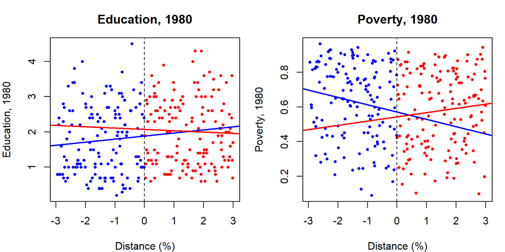

```r
cols <- ifelse(transfer3$above == 1, "red", "blue")

par(mfrow = c(1, 2), mar = c(4, 4, 3, 1))

plot(transfer3$dist_cutoff, transfer3$educ80, pch = 16, cex = 0.6,
     col = cols, xlab = "Distance (%)", ylab = "Education, 1980",
     main = "Education, 1980")
abline(v = 0, lty = 2)
abline(lm(educ80 ~ dist_cutoff, data = subset(transfer3, above == 0)), col = "blue", lwd = 2)
abline(lm(educ80 ~ dist_cutoff, data = subset(transfer3, above == 1)), col = "red", lwd = 2)

plot(transfer3$dist_cutoff, transfer3$poverty80, pch = 16, cex = 0.6,
     col = cols, xlab = "Distance (%)", ylab = "Poverty, 1980",
     main = "Poverty, 1980")
abline(v = 0, lty = 2)
abline(lm(poverty80 ~ dist_cutoff, data = subset(transfer3, above == 0)), col = "blue", lwd = 2)
abline(lm(poverty80 ~ dist_cutoff, data = subset(transfer3, above == 1)), col = "red", lwd = 2)
```

```r
par(mfrow = c(1, 1))
```

# Conclusion

Overall, the RDD results are consistent with the idea that additional transfers improved social outcomes: education and literacy increase, while poverty decreases. The strongest evidence comes from comparing municipalities very close to the population cutoffs and checking that there were no large pre-treatment differences.